# Homework #4: Regularization and Variable Selection

Jacob Norman  
2024-11-16

This is the fourth assignment for the course *ISE537: Statistical Models for Systems Analytics in Industrial Engineering*. The topic of this assignment is regularization and variable selection, which includes the following techniques:

- Stepwise Regression
- Ridge Regression
- LASSO Regression
- Elastic Net Regression

To start, let’s read in the required packages.

```r
#install.packages(c("tidyverse", "glmnet", "boot", leaps", "olsrr"))
library(tidyverse)
library(boot)
library(leaps)
library(glmnet)
```

The data set for this assignment was obtained from the [UCI Machine Learning Repository](https://archive.ics.uci.edu/dataset/510/qsar+bioconcentration+classes+dataset). This one is used for QSAR modeling. The following attributes are included:

- `nHM`: Number of heavy atoms
- `piPC09`: Molecular multiple path count
- `PCD`: Difference between multiple path count and path count
- `X2Av`: Average valence connectivity
- `MLOGP`: Moriguchi octanol-water partition coefficient
- `ON1V`: Overall modified Zagreb index by valence vertex degrees
- `N-072`: Frequency of RCO-N fragments
- `B02[C-N]`: 1: Presence of C-N atom pairs; 0: absence of C-N atom pairs.
- `F04[C-O]`: Frequency of C-O atom pairs
- `logBCF`: Bioconcentration Factor in log units

Most of these fields mean nothing to me, but we will proceed with the analysis. Let’s read in the data as a `tibble` from the supplied CSV file and view its structure.

```r
data <- read_csv("data/Bio_pred.csv")
summary(data)
```

```
      nHM             piPC09           PCD             X2Av
 Min.   : 0.000   Min.   :0.000   Min.   :0.000   Min.   :0.0900
 1st Qu.: 0.000   1st Qu.:0.000   1st Qu.:1.210   1st Qu.:0.1700
 Median : 1.000   Median :4.263   Median :1.400   Median :0.2000
 Mean   : 1.755   Mean   :3.468   Mean   :1.551   Mean   :0.2369
 3rd Qu.: 3.000   3rd Qu.:6.250   3rd Qu.:2.285   3rd Qu.:0.2400
 Max.   :12.000   Max.   :9.316   Max.   :5.900   Max.   :2.2300
     MLOGP             ON1V          N-072           B02[C-N]
 Min.   :-1.960   Min.   :0.08   Min.   :0.0000   Min.   :0.0000
 1st Qu.: 2.190   1st Qu.:0.91   1st Qu.:0.0000   1st Qu.:0.0000
 Median : 3.130   Median :1.27   Median :0.0000   Median :0.0000
 Mean   : 3.202   Mean   :1.51   Mean   :0.1861   Mean   :0.4236
 3rd Qu.: 4.235   3rd Qu.:2.02   3rd Qu.:0.0000   3rd Qu.:1.0000
 Max.   : 8.320   Max.   :7.19   Max.   :3.0000   Max.   :1.0000
    F04[C-O]          logBCF
 Min.   : 0.000   Min.   :-1.700
 1st Qu.: 0.000   1st Qu.: 0.985
 Median : 2.000   Median : 2.030
 Mean   : 3.585   Mean   : 2.063
 3rd Qu.: 6.000   3rd Qu.: 2.950
 Max.   :25.000   Max.   : 6.060
```

To facilitate our later analysis, let’s split that data 80-20 into training and testing data sets, respectively.

```r
set.seed(100)
test_rows <- sample(nrow(data), 0.2 * nrow(data))

test <- data[test_rows, ]
train <- data[-test_rows,]
```

### Question 1. Full Model

To begin, let’s fit a linear regression model with `logBCF` as the response and all other variables as the predictors.

```r
model1 <- lm(logBCF ~ ., train)
summary(model1)
```

```
Call:
lm(formula = logBCF ~ ., data = train)

Residuals:
    Min      1Q  Median      3Q     Max
-3.2577 -0.5180  0.0448  0.5117  4.0423

Coefficients:
             Estimate Std. Error t value Pr(>|t|)
(Intercept)  0.001422   0.138057   0.010  0.99179
nHM          0.137022   0.022462   6.100 1.88e-09 ***
piPC09       0.031158   0.020874   1.493  0.13603
PCD          0.055655   0.063874   0.871  0.38391
X2Av        -0.031890   0.253574  -0.126  0.89996
MLOGP        0.506088   0.034211  14.793  < 2e-16 ***
ON1V         0.140595   0.066810   2.104  0.03575 *
`N-072`     -0.073334   0.070993  -1.033  0.30202
`B02[C-N]`  -0.158231   0.080143  -1.974  0.04879 *
`F04[C-O]`  -0.030763   0.009667  -3.182  0.00154 **
---
Signif. codes:  0 '***' 0.001 '**' 0.01 '*' 0.05 '.' 0.1 ' ' 1

Residual standard error: 0.7957 on 614 degrees of freedom
Multiple R-squared:  0.6672,    Adjusted R-squared:  0.6623
F-statistic: 136.8 on 9 and 614 DF,  p-value: < 2.2e-16
```

At the 95 percent confidence level, the following coefficients are significant:

- `nHM`
- `MLOGP`
- `ON1V`
- `B02[C-N]`
- `F04[C-O]`

However at the 99 percent confidence level, only three coefficients are still significant:

- `nHM`
- `MLOGP`
- `F04[C-O]`

Let’s now compute the **C**ross **V**alidation (CV) scores for 10-fold cross validation and leave-one-out cross validation. We will use the `boot` package to achieve this and use the function default for the cost function, **M**ean **S**quared **P**rediction **E**rror (MSPE).

```r
# compute cv scores for 10-fold and leave-one-out cross validation
fold_10 <- cv.glm(train, glm(logBCF ~ ., data = train), K = 10)$delta
leave_one_out <- cv.glm(train, glm(logBCF ~ ., data = train), K = nrow(train))$delta

# combine results into summary tibble
cv_scores <- rbind(fold_10, leave_one_out)
colnames(cv_scores) <- c("Raw MSPE", "Adjusted MSPE")
add_column(as_tibble(cv_scores), `CV Type` = c("10-fold", "Leave-one-out"), .before = 1)
```

```
# A tibble: 2 × 3
  `CV Type`     `Raw MSPE` `Adjusted MSPE`
  <chr>              <dbl>           <dbl>
1 10-fold            0.653           0.651
2 Leave-one-out      0.653           0.653
```

Both error measures are almost equivalent for the two different CV methods. Let’s now compute the AIC, BIC, and Mallow’s $C_p$ values for the full model.

```r
aic1 <- AIC(model1)
bic1 <- BIC(model1)
cp1 <- olsrr::ols_mallows_cp(model1, model1)

tibble(Model = "model1", AIC = aic1, BIC = bic1, Cp = cp1)
```

```
# A tibble: 1 × 4
  Model    AIC   BIC    Cp
  <chr>  <dbl> <dbl> <dbl>
1 model1 1497. 1546.    10
```

Let’s fit a new model using only the three predictors that were significant at the 99 percent confidence level and call it `model2`.

```r
model2 <- lm(logBCF ~ nHM + MLOGP + `F04[C-O]`, train)
summary(model2)
```

```
Call:
lm(formula = logBCF ~ nHM + MLOGP + `F04[C-O]`, data = train)

Residuals:
    Min      1Q  Median      3Q     Max
-3.2555 -0.5097  0.0374  0.5471  4.2704

Coefficients:
            Estimate Std. Error t value Pr(>|t|)
(Intercept) -0.03076    0.07836  -0.393   0.6948
nHM          0.10948    0.01762   6.213 9.56e-10 ***
MLOGP        0.60993    0.02177  28.018  < 2e-16 ***
`F04[C-O]`  -0.01295    0.00745  -1.738   0.0826 .
---
Signif. codes:  0 '***' 0.001 '**' 0.01 '*' 0.05 '.' 0.1 ' ' 1

Residual standard error: 0.8037 on 620 degrees of freedom
Multiple R-squared:  0.6571,    Adjusted R-squared:  0.6554
F-statistic:   396 on 3 and 620 DF,  p-value: < 2.2e-16
```

To test the significance of the predictors that we removed from the model, let’s use an ANOVA test on this reduced model against the full model.

```r
anova(model1, model2)
```

```
Analysis of Variance Table

Model 1: logBCF ~ nHM + piPC09 + PCD + X2Av + MLOGP + ON1V + `N-072` +
    `B02[C-N]` + `F04[C-O]`
Model 2: logBCF ~ nHM + MLOGP + `F04[C-O]`
  Res.Df    RSS Df Sum of Sq     F  Pr(>F)
1    614 388.70
2    620 400.51 -6   -11.809 3.109 0.00523 **
---
Signif. codes:  0 '***' 0.001 '**' 0.01 '*' 0.05 '.' 0.1 ' ' 1
```

Based on a significance level of $\alpha=0.01$, we reject the null hypothesis that all of the additional predictors in the full model have coefficients equal to zero. In other words, we conclude that these predictors cannot all be removed with no loss in explainability. Based on this result, it is not good practice simply to select the most significant predictors based on the full model alone; a variable selection technique, such as stepwise or LASSO regression, would be more appropriate.

### Question 2. Full Model Search

We will now begin variable selection starting with the full model, `model1`. To make things easier, let’s separate the `response` from the `predictors`.

```r
response <- train$logBCF
predictors <- train %>% select(-logBCF)
```

Let’s enumerate through all possible combinations of predictors and display the best model for each number based on the lowest value of Mallow’s $C_p$.

```r
# select best model predictors using Cp
cp_output <- leaps(predictors, response, method = "Cp",
                   nbest = 1, names = names(predictors))

# manipulate output into nicely formatted tibble
cp_tibble <- as_tibble(cp_output$which)
cp_tibble$Cp <- cp_output$Cp
cp_tibble$size <- cp_output$size

# display tibble
cp_tibble %>%
  select(size, Cp, everything())
```

```
# A tibble: 9 × 11
   size    Cp nHM   piPC09 PCD   X2Av  MLOGP ON1V  `N-072` `B02[C-N]` `F04[C-O]`
  <dbl> <dbl> <lgl> <lgl>  <lgl> <lgl> <lgl> <lgl> <lgl>   <lgl>      <lgl>
1     2 58.6  FALSE FALSE  FALSE FALSE TRUE  FALSE FALSE   FALSE      FALSE
2     3 17.7  TRUE  FALSE  FALSE FALSE TRUE  FALSE FALSE   FALSE      FALSE
3     4 15.2  TRUE  TRUE   FALSE FALSE TRUE  FALSE FALSE   FALSE      FALSE
4     5  9.50 TRUE  TRUE   FALSE FALSE TRUE  FALSE FALSE   FALSE      TRUE
5     6  7.24 TRUE  TRUE   FALSE FALSE TRUE  FALSE FALSE   TRUE       TRUE
6     7  6.12 TRUE  TRUE   FALSE FALSE TRUE  TRUE  FALSE   TRUE       TRUE
7     8  6.83 TRUE  TRUE   FALSE FALSE TRUE  TRUE  TRUE    TRUE       TRUE
8     9  8.02 TRUE  TRUE   TRUE  FALSE TRUE  TRUE  TRUE    TRUE       TRUE
9    10 10    TRUE  TRUE   TRUE  TRUE  TRUE  TRUE  TRUE    TRUE       TRUE
```

The total number of possible models with the full set of variables included is only one, since $\binom{9}{9}=1$. The model will the lowest $C_p$ value has seven total predictors, including the intercept. This includes:

- `nHM`
- `piPC09`
- `MLOGP`
- `ON1V`
- `B02[C-N]`
- `F04[C-O]`

Let’s fit this as a new model and call it `model3`.

```r
model3 <- lm(logBCF ~ nHM + piPC09 + MLOGP + ON1V + `B02[C-N]` + `F04[C-O]`, train)
summary(model3)
```

```
Call:
lm(formula = logBCF ~ nHM + piPC09 + MLOGP + ON1V + `B02[C-N]` +
    `F04[C-O]`, data = train)

Residuals:
    Min      1Q  Median      3Q     Max
-3.2364 -0.5234  0.0421  0.5196  4.1159

Coefficients:
             Estimate Std. Error t value Pr(>|t|)
(Intercept)  0.035785   0.099454   0.360  0.71911
nHM          0.124086   0.019083   6.502 1.63e-10 ***
piPC09       0.042167   0.014135   2.983  0.00297 **
MLOGP        0.528522   0.029434  17.956  < 2e-16 ***
ON1V         0.098099   0.055457   1.769  0.07740 .
`B02[C-N]`  -0.160204   0.073225  -2.188  0.02906 *
`F04[C-O]`  -0.028644   0.009415  -3.042  0.00245 **
---
Signif. codes:  0 '***' 0.001 '**' 0.01 '*' 0.05 '.' 0.1 ' ' 1

Residual standard error: 0.7951 on 617 degrees of freedom
Multiple R-squared:  0.666, Adjusted R-squared:  0.6628
F-statistic: 205.1 on 6 and 617 DF,  p-value: < 2.2e-16
```

### Question 3. Stepwise Regression

Now let’s conduct a similar analysis using stepwise regression, starting with backward elimination using BIC.

```r
model0 <- lm(logBCF ~ 1, train) # intercept only model
model4 <- step(model1, scope = list(lower = model0, upper = model1),
               direction = "backward", k = log(nrow(train)))
```

```
Start:  AIC=-231
logBCF ~ nHM + piPC09 + PCD + X2Av + MLOGP + ON1V + `N-072` +
    `B02[C-N]` + `F04[C-O]`

             Df Sum of Sq    RSS      AIC
- X2Av        1     0.010 388.71 -237.417
- PCD         1     0.481 389.18 -236.662
- `N-072`     1     0.676 389.38 -236.350
- piPC09      1     1.411 390.11 -235.173
- `B02[C-N]`  1     2.468 391.17 -233.484
- ON1V        1     2.804 391.51 -232.949
<none>                    388.70 -230.997
- `F04[C-O]`  1     6.410 395.11 -227.226
- nHM         1    23.557 412.26 -200.718
- MLOGP       1   138.539 527.24  -47.211

Step:  AIC=-237.42
logBCF ~ nHM + piPC09 + PCD + MLOGP + ON1V + `N-072` + `B02[C-N]` +
    `F04[C-O]`

             Df Sum of Sq    RSS      AIC
- PCD         1     0.517 389.23 -243.025
- `N-072`     1     0.667 389.38 -242.783
- piPC09      1     1.423 390.14 -241.574
- `B02[C-N]`  1     2.510 391.22 -239.838
- ON1V        1     2.915 391.63 -239.192
<none>                    388.71 -237.417
- `F04[C-O]`  1     6.491 395.21 -233.520
- nHM         1    25.431 414.15 -204.309
- MLOGP       1   146.081 534.80  -44.772

Step:  AIC=-243.02
logBCF ~ nHM + piPC09 + MLOGP + ON1V + `N-072` + `B02[C-N]` +
    `F04[C-O]`

             Df Sum of Sq    RSS      AIC
- `N-072`     1     0.813 390.04 -248.159
- `B02[C-N]`  1     2.099 391.33 -246.105
- ON1V        1     2.412 391.64 -245.606
<none>                    389.23 -243.025
```

[output cut: 22 more lines]

```
- `F04[C-O]`  1     3.902 395.92 -251.695
<none>                    392.02 -251.438
- piPC09      1     7.252 399.27 -246.437
- nHM         1    25.197 417.22 -219.003
- MLOGP       1   247.006 639.03   47.031

Step:  AIC=-253.6
logBCF ~ nHM + piPC09 + MLOGP + `F04[C-O]`

             Df Sum of Sq    RSS      AIC
<none>                    394.72 -253.602
- `F04[C-O]`  1     4.868 399.58 -252.390
- piPC09      1     5.798 400.51 -250.939
- nHM         1    26.847 421.56 -218.977
- MLOGP       1   302.931 697.65   95.359
```

```r
summary(model4)
```

```
Call:
lm(formula = logBCF ~ nHM + piPC09 + MLOGP + `F04[C-O]`, data = train)

Residuals:
    Min      1Q  Median      3Q     Max
-3.2611 -0.5126  0.0517  0.5353  4.3488

Coefficients:
             Estimate Std. Error t value Pr(>|t|)
(Intercept) -0.008695   0.078196  -0.111  0.91150
nHM          0.114029   0.017574   6.489 1.78e-10 ***
piPC09       0.041119   0.013636   3.015  0.00267 **
MLOGP        0.566473   0.025990  21.796  < 2e-16 ***
`F04[C-O]`  -0.022104   0.008000  -2.763  0.00590 **
---
Signif. codes:  0 '***' 0.001 '**' 0.01 '*' 0.05 '.' 0.1 ' ' 1

Residual standard error: 0.7985 on 619 degrees of freedom
Multiple R-squared:  0.662, Adjusted R-squared:  0.6599
F-statistic: 303.1 on 4 and 619 DF,  p-value: < 2.2e-16
```

Using backward elimination, there are four predictors in addition to the intercept:

- `nHM`
- `piPC09`
- `MLOGP`
- `F04[C-O]`

All of the predictors of `model4`, except the intercept, are significant at the 99 percent confidence level.

We will now perform a similar analysis using forward selection and AIC.

```r
model5 <- step(model0, scope = list(lower = model0, upper = model1),
               direction = "forward")
```

```
Start:  AIC=393.14
logBCF ~ 1

             Df Sum of Sq     RSS     AIC
+ MLOGP       1    738.32  429.60 -228.94
+ nHM         1    255.66  912.25  240.98
+ piPC09      1    220.90  947.02  264.31
+ PCD         1    150.75 1017.17  308.90
+ `B02[C-N]`  1    139.23 1028.68  315.93
+ `N-072`     1     43.55 1124.37  371.43
+ ON1V        1     27.76 1140.16  380.13
+ `F04[C-O]`  1     20.79 1147.13  383.93
<none>                    1167.92  393.14
+ X2Av        1      2.45 1165.46  393.83

Step:  AIC=-228.94
logBCF ~ MLOGP

             Df Sum of Sq    RSS     AIC
+ nHM         1   27.1327 402.47 -267.65
+ `B02[C-N]`  1    4.1778 425.42 -233.04
+ `F04[C-O]`  1    4.1526 425.45 -233.00
+ X2Av        1    3.2819 426.32 -231.72
+ ON1V        1    2.3664 427.23 -230.38
<none>                    429.60 -228.94
+ piPC09      1    1.0443 428.55 -228.46
+ `N-072`     1    0.2481 429.35 -227.30
+ PCD         1    0.1198 429.48 -227.11

Step:  AIC=-267.65
logBCF ~ MLOGP + nHM

             Df Sum of Sq    RSS     AIC
+ piPC09      1   2.88247 399.58 -270.13
+ `F04[C-O]`  1   1.95225 400.51 -268.68
+ `B02[C-N]`  1   1.93200 400.53 -268.65
<none>                    402.47 -267.65
+ PCD         1   1.23679 401.23 -267.57
+ `N-072`     1   0.40989 402.06 -266.29
+ ON1V        1   0.33115 402.13 -266.16
```

[output cut: 28 more lines]

```
          Df Sum of Sq    RSS     AIC
+ ON1V     1   1.97807 390.04 -279.21
<none>                 392.02 -278.06
+ `N-072`  1   0.37905 391.64 -276.66
+ X2Av     1   0.12543 391.90 -276.25
+ PCD      1   0.00000 392.02 -276.06

Step:  AIC=-279.21
logBCF ~ MLOGP + nHM + piPC09 + `F04[C-O]` + `B02[C-N]` + ON1V

          Df Sum of Sq    RSS     AIC
<none>                 390.04 -279.21
+ `N-072`  1   0.81306 389.23 -278.51
+ PCD      1   0.66238 389.38 -278.27
+ X2Av     1   0.02794 390.02 -277.26
```

```r
summary(model5)
```

```
Call:
lm(formula = logBCF ~ MLOGP + nHM + piPC09 + `F04[C-O]` + `B02[C-N]` +
    ON1V, data = train)

Residuals:
    Min      1Q  Median      3Q     Max
-3.2364 -0.5234  0.0421  0.5196  4.1159

Coefficients:
             Estimate Std. Error t value Pr(>|t|)
(Intercept)  0.035785   0.099454   0.360  0.71911
MLOGP        0.528522   0.029434  17.956  < 2e-16 ***
nHM          0.124086   0.019083   6.502 1.63e-10 ***
piPC09       0.042167   0.014135   2.983  0.00297 **
`F04[C-O]`  -0.028644   0.009415  -3.042  0.00245 **
`B02[C-N]`  -0.160204   0.073225  -2.188  0.02906 *
ON1V         0.098099   0.055457   1.769  0.07740 .
---
Signif. codes:  0 '***' 0.001 '**' 0.01 '*' 0.05 '.' 0.1 ' ' 1

Residual standard error: 0.7951 on 617 degrees of freedom
Multiple R-squared:  0.666, Adjusted R-squared:  0.6628
F-statistic: 205.1 on 6 and 617 DF,  p-value: < 2.2e-16
```

Using forward selection with AIC resulted in a model that has a different number of predictors when compared to `model4`. The same four selected using backward elimination are included, plus two additional ones:

- `B02[C-N]`
- `ON1V`

Let’s compare these stepwise models against the full model for several different measures.

```r
adj_rsq1 <- summary(model1)$adj.r.squared

aic3 <- AIC(model3)
bic3 <- BIC(model3)
cp3 <- olsrr::ols_mallows_cp(model3, model1)
adj_rsq3 <- summary(model3)$adj.r.squared

aic4 <- AIC(model4)
bic4 <- BIC(model4)
cp4 <- olsrr::ols_mallows_cp(model4, model1)
adj_rsq4 <- summary(model4)$adj.r.squared

tibble(Model = c("model1", "model3", "model4"),
       AIC = c(aic1, aic3, aic4),
       BIC = c(bic1, bic3, bic4),
       Cp = c(cp1, cp3, cp4),
       `Adj. R2` = c(adj_rsq1, adj_rsq3, adj_rsq4))
```

```
# A tibble: 3 × 5
  Model    AIC   BIC    Cp `Adj. R2`
  <chr>  <dbl> <dbl> <dbl>     <dbl>
1 model1 1497. 1546. 10        0.662
2 model3 1494. 1529.  6.12     0.663
3 model4 1497. 1524.  9.50     0.660
```

Using the above measures to evaluate the models, I would select `model3` as the preferred model. This is because it has the best AIC, Mallow’s $C_p$, and adjusted $R^2$ value among the three models. The BIC for `model3` is slightly higher than `model4`, but it has by far the best Mallow’s $C_p$.

### Question 4. Ridge Regression

Let us now conduct a ridge regression analysis to deal with potential multicollinearity issues. First, we need to determine the optimal $\lambda$ using 10-fold cross validation.

```r
# convert tibble of predictors to matrix
Xpred <- as.matrix(predictors)

# run 10-fold cv for ridge
ridge_cv <- cv.glmnet(Xpred, response, nfolds = 10, alpha = 0)

# determine optimal lambda
lambda_opt_ridge <- ridge_cv$lambda.min
```

The optimal value of $\lambda$ that minimizes the cross validation error is $\lambda^*=$ 0.1088. Let’s now list the coefficients at this value:

```r
model_ridge <- glmnet(Xpred, response, alpha = 0)
coef(model_ridge, s = lambda_opt_ridge)
```

```
10 x 1 sparse Matrix of class "dgCMatrix"
                     s1
(Intercept)  0.13841426
nHM          0.14391877
piPC09       0.03735762
PCD          0.08235334
X2Av        -0.06901352
MLOGP        0.44403655
ON1V         0.15770114
N-072       -0.09683534
B02[C-N]    -0.20919397
F04[C-O]    -0.03177144
```

We can see that *all* of the variables are selected. This is because ridge regression is not a variable selection technique, but rather is used for regularization.

Instead, the estimated model coefficients are different from what we observed in our full model. This attempts to adjust for potential multicollinearity. Interestingly, the magnitude of almost all of the coefficients is larger than we have observed in the full model. Let’s plot the path of the coefficients to investigate further:

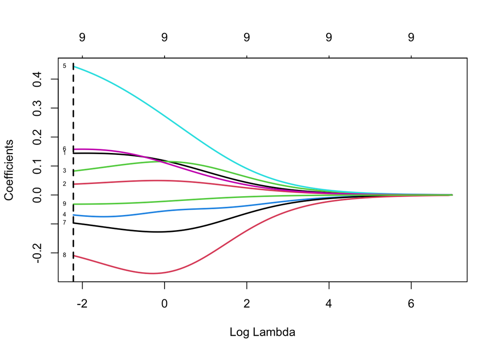

```r
plot(model_ridge, xvar = "lambda", lwd = 2, label = TRUE)
abline(v = log(lambda_opt_ridge), lwd = 2, lty = 2) # optimal lambda
```

We can observe that there is a bow shape to many of the coefficient paths, implying that there are values of $\lambda$ where the magnitude of the coefficients is larger in ridge regression than in the ordinary least squares model. This might explain why there seems to be no shrinkage.

### Question 5. LASSO Regression

Let’s now use the `glmnet` package to fit a LASSO regression to determine which variables should be selected. This is very similar to what we did in the last problem, but we need to adjust $\alpha=1$ to force it to a LASSO model.

```r
# run 10-fold cv for lasso
lasso_cv <- cv.glmnet(Xpred, response, nfolds = 10, alpha = 1)

# determine optimal lambda
lambda_opt_lasso <- lasso_cv$lambda.min
```

The optimal value of $\lambda$ that minimizes the cross validation error is $\lambda^*=$ 0.0072. What does the regression coefficient path plot look like as $\lambda$ varies?

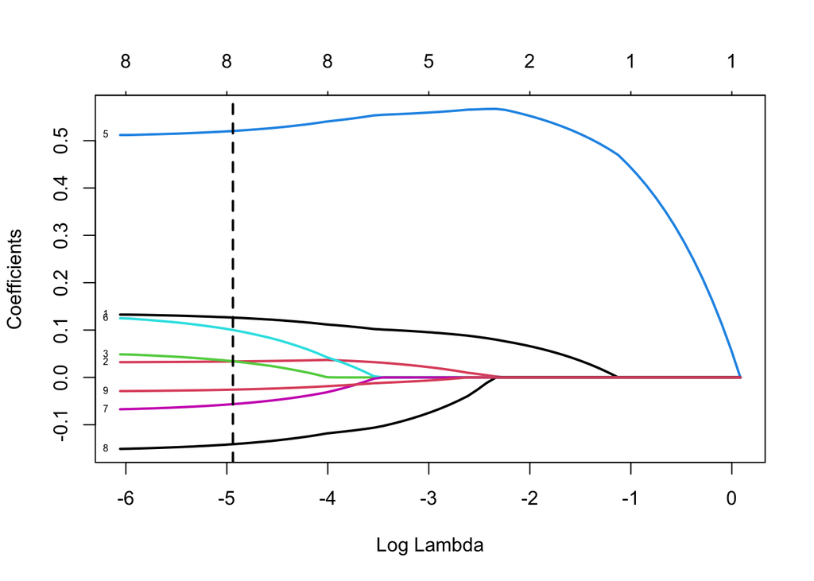

```r
# fit lasso model
model_lasso <- glmnet(Xpred, response, alpha = 1)

# plot coefficient paths
plot(model_lasso, xvar = "lambda", lwd = 2, label = TRUE)
abline(v = log(lambda_opt_lasso), lwd = 2, lty = 2) # optimal lambda
```

Nine variables are selected using this value of $\lambda$; let’s see what they are:

```r
coef(model_lasso, s = lambda_opt_lasso)
```

```
10 x 1 sparse Matrix of class "dgCMatrix"
                     s1
(Intercept)  0.02405988
nHM          0.12639358
piPC09       0.03364600
PCD          0.03416564
X2Av         .
MLOGP        0.52043765
ON1V         0.10007272
N-072       -0.05645698
B02[C-N]    -0.14108636
F04[C-O]    -0.02581899
```

The LASSO regression selected all variables (including the intercept) except `X2Av`.

### Question 6. Elastic Net

We will repeat the same analysis with `glmnet` again, this time setting $\alpha=0.5$ to specify elastic net with equal weight to ridge and LASSO penalties.

```r
# run 10-fold cv for elastic net
net_cv <- cv.glmnet(Xpred, response, nfolds = 10, alpha = 0.5)

# determine optimal lambda
lambda_opt_net <- net_cv$lambda.min
```

The optimal value of $\lambda$ that minimizes the cross validation error is $\lambda^*=$ 0.0228. Let’s see which variables are selected using this parameter.

```r
model_net <- glmnet(Xpred, response, alpha = 0.5)
coef(model_net, s = lambda_opt_net)
```

```
10 x 1 sparse Matrix of class "dgCMatrix"
                     s1
(Intercept)  0.05442259
nHM          0.12285188
piPC09       0.03499112
PCD          0.02824993
X2Av         .
MLOGP        0.51870645
ON1V         0.08446251
N-072       -0.05041668
B02[C-N]    -0.14020962
F04[C-O]    -0.02360516
```

Using elastic net, the same nine variables (including intercept) are selected as those determined by LASSO regression. However, they have different values compared to the LASSO model since there is a ridge component being applied to them.

### Question 7. Model Comparison

Let’s bring everything together and test several models against our `test` tibble we defined earlier. Specifically, we will be comparing:

- `model1`: Full model
- `model4`: Stepwise regression using backward elimination and BIC
- `model_ridge`: Ridge regression
- `model_lasso`: LASSO regression
- `model_net`: Equally-weighted elastic net regression

```r
# convert predictors of test tibble to matrix
Xtest <- test %>%
          select(-logBCF) %>%
          as.matrix()

# predict based on specified model
test$predict_full <- predict(model1, test)
test$predict_back <- predict(model4, test)
test$predict_ridge <- predict(model_ridge, Xtest, s = lambda_opt_ridge)
test$predict_lasso <- predict(model_lasso, Xtest, s = lambda_opt_lasso)
test$predict_net <- predict(model_net, Xtest, s = lambda_opt_net)

test %>%
  select(logBCF, predict_full, predict_back, predict_ridge, predict_lasso, predict_net) %>%
  head(10)
```

```
# A tibble: 10 × 6
   logBCF predict_full predict_back predict_ridge[,"s1"] predict_lasso[,"s1"]
    <dbl>        <dbl>        <dbl>                <dbl>                <dbl>
 1   2.64        2.45         2.42                 2.45                 2.44
 2   4.58        4.33         4.35                 4.23                 4.32
 3   3.44        3.27         3.27                 3.22                 3.26
 4   0.67        1.66         1.30                 1.73                 1.61
 5   2.61        1.96         2.00                 1.99                 1.94
 6   4.81        4.33         4.36                 4.23                 4.32
 7   0.9         1.17         1.23                 1.17                 1.18
 8   0.99        0.792        0.975                0.778                0.867
 9   0.83        0.976        1.04                 0.988                0.985
10  -0.16        0.897        0.757                0.963                0.887
# ℹ 1 more variable: predict_net <dbl[,1]>
```

Now we will compute the MSPE to determine which model performed the best.

```r
# compute mean squared prediction error for each model's predictions
mspe_full <- mean((test$logBCF - test$predict_full)^2)
mspe_back <- mean((test$logBCF - test$predict_back)^2)
mspe_ridge <- mean((test$logBCF - test$predict_ridge)^2)
mspe_lasso <- mean((test$logBCF - test$predict_lasso)^2)
mspe_net <- mean((test$logBCF - test$predict_net)^2)

# summmarize results in tibble
tibble(Model = c("model1", "model4", "model_ridge", "model_lasso", "model_net"),
       Method = c("Full", "Backward Stepwise", "Ridge", "LASSO", "Elastic Net"),
       MSPE = c(mspe_full, mspe_back, mspe_ridge, mspe_lasso, mspe_net))
```

```
# A tibble: 5 × 3
  Model       Method             MSPE
  <chr>       <chr>             <dbl>
1 model1      Full              0.584
2 model4      Backward Stepwise 0.574
3 model_ridge Ridge             0.588
4 model_lasso LASSO             0.579
5 model_net   Elastic Net       0.578
```

Using MSPE as our criterion, the backward stepwise regression model using BIC performed the best. The corresponds to `model4`. Since the response variable is on a log scale, the MSPEs are all quite close.

Let’s compare which variables are selected by each of the five models we have been investigating in this problem.

```r
tibble(Variable = names(predictors),
       Full = rep(1, 9),
       `Backward Stepwise` = c(1, 1, 0, 0, 1, 0, 0, 0, 1),
       Ridge = rep(1, 9),
       LASSO = c(1, 1, 1, 0, 1, 1, 1, 1, 1),
       `Elastic Net` = c(1, 1, 1, 0, 1, 1, 1, 1, 1))
```

```
# A tibble: 9 × 6
  Variable  Full `Backward Stepwise` Ridge LASSO `Elastic Net`
  <chr>    <dbl>               <dbl> <dbl> <dbl>         <dbl>
1 nHM          1                   1     1     1             1
2 piPC09       1                   1     1     1             1
3 PCD          1                   0     1     1             1
4 X2Av         1                   0     1     0             0
5 MLOGP        1                   1     1     1             1
6 ON1V         1                   0     1     1             1
7 N-072        1                   0     1     1             1
8 B02[C-N]     1                   0     1     1             1
9 F04[C-O]     1                   1     1     1             1
```

The variables `nHM`, `piPC09`, `MLOGP`, and `F04[C-O]` were selected by every single method. Interestingly, `X2Av` was only selected by the full model and the ridge regression model. These models do not exclude any variables by design, so we can be confident not to include this variable as a predictor in any model we build.